# Advanced MCMCglmm

# Imputing data

Another neat ability of using MCMCglmm is the ability to impute data. Imputation is essentially estimating some values for missing data using information from other linked data. This could be as simple as using the mean of some distribution or more usefully using the some correlative structure such as calculating expected values in a glm. However, MCMCglmm will automatically impute missing data in the response variable allowing you carry out an analysis with some missing data.

```r
#missing data for ten and a 100 random species
index10 <- round(runif(10,1,length(mcmc_data$longevity)))
index100 <- round(runif(100,1,length(mcmc_data$longevity)))

#And replace them with NA
lifespan10 <-  mcmc_data$longevity
lifespan100 <-  mcmc_data$longevity
lifespan10[index10] <- NA
lifespan100[index100] <- NA



####and create a new dataframe to keep things clean
mcmc_data <- data.frame(lifespan10,lifespan100,mcmc_data)
```

Like before we need a prior

```r
prior3 <- list(R = list(V=1, nu=0.002),
              G = list(G1 = list(V=1, nu=0.002)))
```

and some paramters

```r
#no. of interations
nitt3 <- c(12000)
#length of burnin
burnin3 <- c(2000)
#amount of thinning
thin3 <- c(5)
```

Now we can run our models with missing models. We dont need to but if we want to record the imputed lifespans of the missing species we can use the pl = TRUE argument.

```r
mcmc_imput_10 <- MCMCglmm(fixed =  lifespan10 ~ mass + volant,
                     random= ~ animal,
                     family="gaussian",
                     pedigree = mcmc_tree,
                     data = mcmc_data,
                     nitt = nitt3,
                     burnin = burnin3,
                     thin = thin3,
                     prior = prior3,
                     verbose=FALSE,
                     pl = TRUE
                     )

summary(mcmc_imput_10)
```

```
##
##  Iterations = 2001:11996
##  Thinning interval  = 5
##  Sample size  = 2000
##
##  DIC: 18.08771
##
##  G-structure:  ~animal
##
##        post.mean l-95% CI u-95% CI eff.samp
## animal     0.603   0.4008   0.8556    683.2
##
##  R-structure:  ~units
##
##       post.mean l-95% CI u-95% CI eff.samp
## units   0.03801  0.01792  0.06203      753
##
##  Location effects: lifespan10 ~ mass + volant
##
##              post.mean l-95% CI u-95% CI eff.samp  pMCMC
## (Intercept)    0.05041 -0.78197  0.82278     2000  0.885
## mass           0.44246  0.28721  0.60498     1721 <5e-04 ***
## volantvolant   1.05302  0.16784  1.87162     2000  0.022 *
## ---
## Signif. codes:  0 '***' 0.001 '**' 0.01 '*' 0.05 '.' 0.1 ' ' 1
```

and now with 100 missing species

```r
mcmc_imput_100 <- MCMCglmm(fixed =  lifespan100 ~ mass + volant,
                     random= ~ animal,
                     family="gaussian",
                     pedigree = mcmc_tree,
                     data = mcmc_data,
                     nitt = nitt3,
                     burnin = burnin3,
                     thin = thin3,
                     prior = prior3,
                     verbose=FALSE,
                     pl = TRUE
                     )

summary(mcmc_imput_100)
```

```
##
##  Iterations = 2001:11996
##  Thinning interval  = 5
##  Sample size  = 2000
##
##  DIC: -62.50104
##
##  G-structure:  ~animal
##
##        post.mean l-95% CI u-95% CI eff.samp
## animal    0.7847   0.4543     1.12      314
##
##  R-structure:  ~units
##
##       post.mean  l-95% CI u-95% CI eff.samp
## units   0.01954 0.0004846   0.0486    160.2
##
##  Location effects: lifespan100 ~ mass + volant
##
##              post.mean l-95% CI u-95% CI eff.samp  pMCMC
## (Intercept)     0.1059  -0.7791   1.1018     2000  0.816
## mass            0.3564   0.1504   0.5508      481 <5e-04 ***
## volantvolant    0.9663  -0.1228   1.9879     1114  0.079 .
## ---
## Signif. codes:  0 '***' 0.001 '**' 0.01 '*' 0.05 '.' 0.1 ' ' 1
```

Even with 100 missing values in the response variable our model runs pretty well.Most of this is likely to be down to the data missing in a random fashion. If say however all the flying species were missing we simply could not run the model.

Since we recorded the imputed estimates we can also get values of lifespans for these species which are stored under the heading Liab

```r
##as the Liab section stores what the values are for each species along each iteration
##(even if the values are fixed) we will only look at the first 10

head(mcmc_imput_100$Liab)[,1:10]
```

[output not shown]

The entries along the column are in the same order as the species along our row so if we want the estimate for the first species.

```r
rownames(mcmc_data[index10[1],])
```

```
## [1] "Saguinus_oedipus"
```

```r
####plot of the first missing species
rownames(mcmc_data[index10[1],])
```

```
## [1] "Saguinus_oedipus"
```

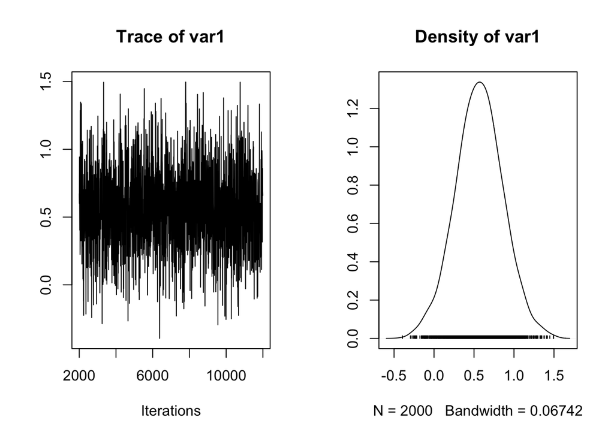

```r
plot(mcmc_imput_10$Liab[,index10[1]])
```

```r
####mean of the first missing species
mean(mcmc_imput_10$Liab[,index10[1]])
```

```
## [1] 0.5667631
```

```r
###and check it with the actual value
mcmc_data[index10[1],c("longevity")]
```

```
## [1] 0.7424312
```

Imputation can be used in any of the models shown before. One of the major advantages is that instead of imputing using models without phylogenetic corrections MCMCglmm allows this along with any number of random terms.